# DATA7440: Final Project

# Problem 2

[50 points]

We will use the api data again for this problem, but this time we are interested in predicting the api test scores for 2000 (i.e. api00) based on a battery of school, teacher and parent information. This time the data and models are available in the apipopProb2.RData R workspace. Note the data sets here are different than for Problem 1.

## Libraries

```r
rm(list = ls())

suppressPackageStartupMessages(library(randomForest)) # Random Forest
suppressPackageStartupMessages(library(pdp)) # pdp
suppressPackageStartupMessages(library(ggplot2)) # ggplot2
suppressPackageStartupMessages(library(iml)) # iml
suppressPackageStartupMessages(library(kableExtra)) # kableExtra
suppressPackageStartupMessages(library(knitr)) # needed for the kable function
suppressPackageStartupMessages(library(ICEbox))

suppressPackageStartupMessages(library(caret))
suppressPackageStartupMessages(library(grid))
suppressPackageStartupMessages(library(gridExtra))
suppressPackageStartupMessages(library(lattice))
suppressPackageStartupMessages(library(xgboost))
suppressPackageStartupMessages(library(glmnet))
suppressPackageStartupMessages(library(rpart))
```

## Dataset

```r
load("./data/external/apipopProb2.RData")
```

## Functions

### F1. PDP1var

```r
PDP1var <- function(model1, var1) {

    pd1 <- partial(model1,
                   pred.var = var1,
                   plot = TRUE,
                   rug = TRUE
                   )

    pd1a <- partial(model1,
                    pred.var = var1,
                    plot = TRUE,
                    plot.engine="ggplot2"
                    )

    pd1a <- pd1a + ggtitle("ggplot2-based PDP")

    grid.arrange(pd1,
                 pd1a,
                 ncol=2
                 )

}
```

### F2. PDP2var

```r
PDP2var <- function(model1, var1, var2) {

    pdp12 <-  partial(model1,
                      pred.var = c(var1, var2),
                      plot = TRUE,
                      chull = TRUE,
                      palette = "magma"
                      )
    pdp12
}
```

### F3. ALE

```r
ALE <- function(model1, feature1, data1, response1){

    predictor1 <- Predictor$new(model = model1,
                                data = data1,
                                y = response1
                                )

    pdp1  <- FeatureEffect$new(predictor1,
                               feature=feature1,
                               method="pdp"
                               )

    ale1  <- FeatureEffect$new(predictor1,
                               feature=feature1
                               )

    grid.arrange(ale1$plot(),
                 pdp1$plot(),
                 ncol=2
                 )
}
```

### F4. Interaction overall

```r
Interaction_overall <- function(model1, data1, response1) {

    predictor1 <- Predictor$new(model1,
                                data = data1,
                                y = response1
                                )
    interact <- Interaction$new(predictor1)
    results_head <- head(interact$results, nrow(interact$results))
    plot_output <- plot(interact)

    output_list <- list(results_head = results_head,
                        plot_output = plot_output
                        )
    return(output_list)
}
```

### F5. Interaction feature spec

```r
Interaction_feature_specific <- function(model1, data1, response1, feature1) {

    predictor1 <- Predictor$new(model1,
                                data = data1,
                                y = response1
                                )
    interact <- Interaction$new(predictor1,
                                feature = feature1
                                )
    results_head <- head(interact$results, nrow(interact$results))
    plot_output <- plot(interact)

    output_list <- list(results_head = results_head,
                        plot_output = plot_output
                        )
    return(output_list)
}
```

## Important predictor

### model 1 VarImp

```r
varImp(model1, scale = FALSE)
```

```
model1 variable importance

  only 20 most important variables shown (out of 72)
```

|  | Overall |
| --- | --- |
| meals | 36.034925 |
| stypeH | 23.873086 |
| ell | 15.095446 |
| stypeM | 14.695049 |
| full | 11.710786 |
| `cnameSan Diego` | 11.050500 |
| pct.resp | 9.787145 |
| cnameOrange | 9.553330 |
| `cnameLos Angeles` | 9.042844 |
| enroll | 8.369579 |

[output cut: 10 more lines]

### model 2 VarImp

```r
varImp(model2, scale = FALSE)
```

```
model2 variable importance

  only 20 most important variables shown (out of 72)
```

|  | Overall |
| --- | --- |
| not.hsg | 1.9447936 |
| avg.ed | 1.8619536 |
| meals | 1.3359520 |
| grad.sch | 1.0332473 |
| ell | 0.7319306 |
| hsg | 0.5961552 |
| some.col | 0.4525073 |
| stypeH | 0.4171871 |
| enroll | 0.3597957 |
| api.stu | 0.1921287 |

[output cut: 10 more lines]

### model 3 VarImp

```r
varImp(model3, scale = FALSE)
```

```
[12:23:44] WARNING: src/objective/regression_obj.cu:213: reg:linear is now deprecated in favor of reg:squarederror.
model3 variable importance

  only 20 most important variables shown (out of 72)
```

|  | Overall |
| --- | --- |
| meals | 0.390101223 |
| avg.ed | 0.214796542 |
| not.hsg | 0.189276865 |
| full | 0.025878181 |
| stypeH | 0.023359827 |
| enroll | 0.022527774 |
| ell | 0.019530776 |
| pct.resp | 0.017719716 |
| api.stu | 0.011752570 |
| emer | 0.011314750 |

[output cut: 10 more lines]

## a. PDP 1-var

PDP 1-var: Partial Dependence plots 1-var

Produce Partial Dependence plots for the most important predictor of each model.

### model1: GLM

GLM: Generalized Linear Model

**Interpretation**:  
A steep straight decline which means a strong negative relationship between “yhat” and “meals”.

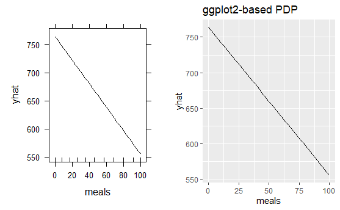

```r
PDP1var(model1, "meals")
```

### model2: CART

CART: Classification And Regression Tree

**Interpretation**:

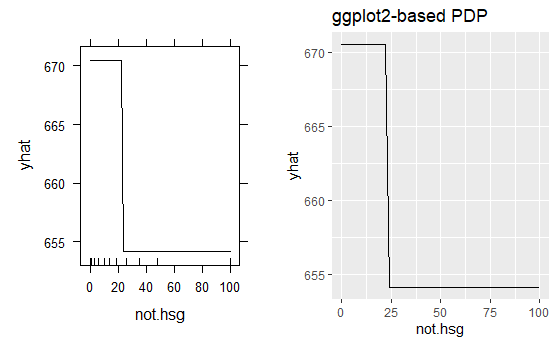

```r
PDP1var(model2, "not.hsg")
```

### model3: XGBoost

XGBoost: eXtreme Gradient Boosting

**Interpretation**:

The curve on a Partial Dependence Plot (PDP) is declining overall but has local ups and downs, it suggests:

1. There may be a non-linear relationship between the predictor variable and the predicted outcome. These local deviations could represent interactions between the predictor variable and other features in the model, or they could suggest that there are specific ranges of the predictor variable where it has a stronger or weaker impact on the predicted outcome.
2. It’s also possible that the local ups and downs in the curve are simply due to noise in the data or limitations of the model. In this case, it’s important to carefully evaluate the quality of the data and the appropriateness of the modeling approach to ensure that the PDP accurately represents the relationship between the predictor variable and the predicted outcome.

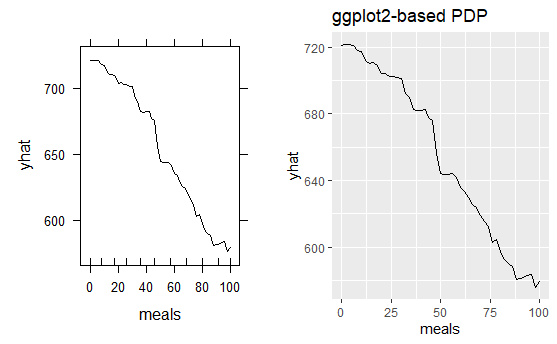

```r
PDP1var(model3, "meals")
```